# EDA - Day 02New

## Bivariate Analysis

- num vs num - Scatterplot
- Categorical vs Numerical - Boxplot

```python
# Pull the Num vars

sales.select_dtypes(include = np.number).columns
```

```
Index(['Item_Weight', 'Item_Visibility', 'Item_MRP',
       'Outlet_Establishment_Year', 'Item_Outlet_Sales', 'Profit'],
      dtype='object')
```

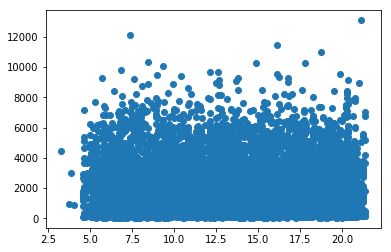

```python
# Item Weight vs Sales
plt.scatter(x = "Item_Weight", y = "Item_Outlet_Sales", data = sales)

# No pattern between Weight and Sales...
```

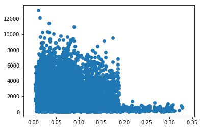

```python
# Item Visibility vs Sales

plt.scatter(x = "Item_Visibility", y = "Item_Outlet_Sales", data = sales)


# Inference As the visibility of the products increases, the sales goes down

# Therefore, one must see the daily consumption based items i.e. essential
# commodities
```

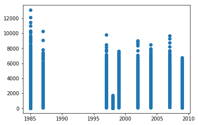

```python
plt.scatter(x = "Outlet_Establishment_Year", y = "Item_Outlet_Sales", data = sales)

# With Est Year, we will calc the Vintage Years for these Outlets
```

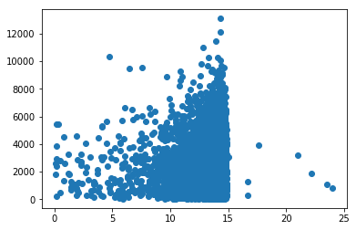

```python
plt.scatter(x = "Profit", y = "Item_Outlet_Sales", data = sales)
```

```python
sales.isnull().sum()
```

```
Item_Identifier                 0
Item_Weight                     0
Item_Fat_Content                0
Item_Visibility                 0
Item_Type                       0
Item_MRP                        0
Outlet_Identifier               0
Outlet_Establishment_Year       0
Outlet_Size                  2410
Outlet_Location_Type         2050
Outlet_Type                     0
Item_Outlet_Sales               0
Profit                          0
dtype: int64
```

```python
sales.select_dtypes(include = "object").columns
```

```
Index(['Item_Identifier', 'Item_Fat_Content', 'Item_Type', 'Outlet_Identifier',
       'Outlet_Size', 'Outlet_Location_Type', 'Outlet_Type'],
      dtype='object')
```

```python
sales.Item_Identifier[0][:2]
```

```
'FD'
```

```python
# Deal with ITEM IDS

# sales.Item_Identifier[0][:2]

list_items = []
for i in sales.Item_Identifier:
    list_items.append(i[:2])
```

```python
sales["Item_Cat"] = pd.Series(list_items)
```

```python
sales.head()
```

|  | Item_Identifier | Item_Weight | Item_Fat_Content | Item_Visibility | Item_Type | Item_MRP | Outlet_Identifier | Outlet_Establishment_Year | Outlet_Size | Outlet_Location_Type | Outlet_Type | Item_Outlet_Sales | Profit | Item_Cat |
| --- | --- | --- | --- | --- | --- | --- | --- | --- | --- | --- | --- | --- | --- | --- |
| 0 | FDA15 | 9.30 | Low Fat | 0.016047 | Dairy | 249.8 | OUT049 | 1999 | Medium | Tier 2 | Supermarket Type1 | 3735.1380 | 11.5 | FD |
| 1 | DRC01 | 5.92 | Regular | 0.019278 | Soft Drinks | 48.3 | OUT018 | 2009 | Medium | Tier 2 | Supermarket Type2 | 443.4228 | 14.3 | DR |
| 2 | FDN15 | 17.50 | Low Fat | 0.016760 | Meat | 141.6 | OUT049 | 1999 | Medium | Tier 2 | Supermarket Type1 | 2097.2700 | 14.5 | FD |
| 3 | FDX07 | 19.20 | Regular | 0.022861 | Fruits and Vegetables | 182.1 | OUT010 | 1998 | NaN | NaN | Grocery Store | 732.3800 | 13.6 | FD |
| 4 | NCD19 | 8.93 | Low Fat | 0.006590 | Household | 53.9 | OUT013 | 1987 | High | Tier 3 | Supermarket Type1 | 994.7052 | 14.1 | NC |

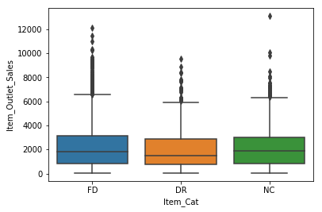

```python
sns.boxplot(x = "Item_Cat", y = "Item_Outlet_Sales", data = sales)
```

```python
# Perishables vs Non Perishables from Item Type

sales.Item_Type.unique()
```

```
array(['Dairy', 'Soft Drinks', 'Meat', 'Fruits and Vegetables',
       'Household', 'Baking Goods', 'Snack Foods', 'Frozen Foods',
       'Breakfast', 'Health and Hygiene', 'Hard Drinks', 'Canned',
       'Breads', 'Starchy Foods', 'Others', 'Seafood'], dtype=object)
```

```python
perishables = ["Dairy", "Meat", "Fruits and Vegetables",
              "Breakfast", "Breads", "Seafood"]
```

```python
def itembadaldo(x):
    if x in perishables:
        return("Perishables")
    else:
        return("Non_Perishables")
```

```python
sales["Item_Type_Cat"] = sales.Item_Type.apply(itembadaldo)
```

```python
sales.head()
```

|  | Item_Identifier | Item_Weight | Item_Fat_Content | Item_Visibility | Item_Type | Item_MRP | Outlet_Identifier | Outlet_Establishment_Year | Outlet_Size | Outlet_Location_Type | Outlet_Type | Item_Outlet_Sales | Profit | Item_Cat | Item_Type_Cat |
| --- | --- | --- | --- | --- | --- | --- | --- | --- | --- | --- | --- | --- | --- | --- | --- |
| 0 | FDA15 | 9.30 | Low Fat | 0.016047 | Dairy | 249.8 | OUT049 | 1999 | Medium | Tier 2 | Supermarket Type1 | 3735.1380 | 11.5 | FD | Perishables |
| 1 | DRC01 | 5.92 | Regular | 0.019278 | Soft Drinks | 48.3 | OUT018 | 2009 | Medium | Tier 2 | Supermarket Type2 | 443.4228 | 14.3 | DR | Non_Perishables |
| 2 | FDN15 | 17.50 | Low Fat | 0.016760 | Meat | 141.6 | OUT049 | 1999 | Medium | Tier 2 | Supermarket Type1 | 2097.2700 | 14.5 | FD | Perishables |
| 3 | FDX07 | 19.20 | Regular | 0.022861 | Fruits and Vegetables | 182.1 | OUT010 | 1998 | NaN | NaN | Grocery Store | 732.3800 | 13.6 | FD | Perishables |
| 4 | NCD19 | 8.93 | Low Fat | 0.006590 | Household | 53.9 | OUT013 | 1987 | High | Tier 3 | Supermarket Type1 | 994.7052 | 14.1 | NC | Non_Perishables |

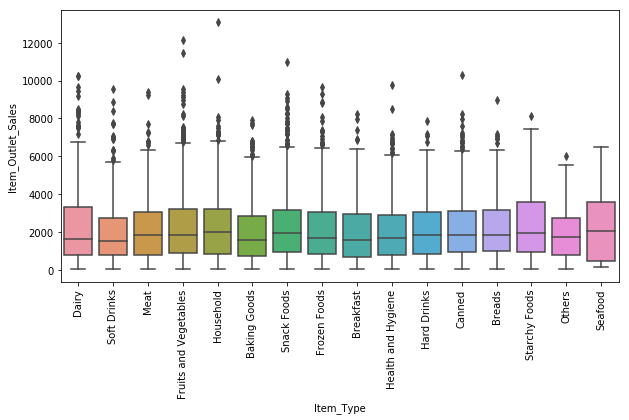

```python
# Item Type vs Sales
plt.figure(figsize=[10,5])
sns.boxplot(x = "Item_Type", y = "Item_Outlet_Sales", data = sales)
plt.xticks(rotation = 90)
plt.show()
```

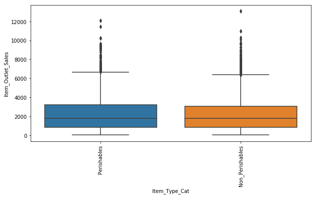

```python
plt.figure(figsize=[10,5])
sns.boxplot(x = "Item_Type_Cat", y = "Item_Outlet_Sales", data = sales)
plt.xticks(rotation = 90)
plt.show()
```

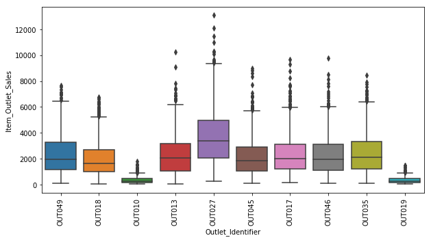

```python
# Outlet ID Vs Sales

plt.figure(figsize=[10,5])
sns.boxplot(x = "Outlet_Identifier", y = "Item_Outlet_Sales", data = sales)
plt.xticks(rotation = 90)
plt.show()
```

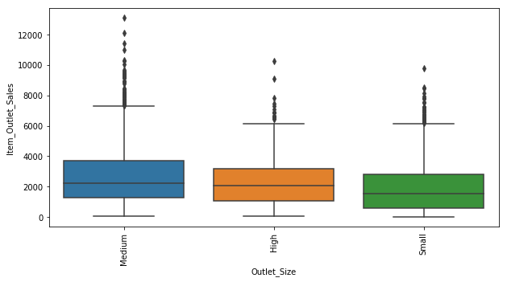

```python
plt.figure(figsize=[10,5])
sns.boxplot(x = "Outlet_Size", y = "Item_Outlet_Sales", data = sales)
plt.xticks(rotation = 90)
plt.show()
```

### Categorical variable Encoding

- One Hot Encoding is a form of Encoding where we treat all the categorical values as same and an identitiy matrix is generated to ensure that each category in the column gets equal weightage. For e.g. pd.get_dummies()
- Label Encoder - It is applied on those cat variables where we see some order such as one is greater than the other. In our data, Outlet Size is a variable which has a certain order (Small, Medium & Large).
- Therein we will apply Label Encoder to Encode the values as 1,2,3... so that machine can understand that one category has more weightage than the other... This is achieved by Label Encoding...

```python
# Item Type vs Outlet Size....
sales.head()
```

|  | Item_Identifier | Item_Weight | Item_Fat_Content | Item_Visibility | Item_Type | Item_MRP | Outlet_Identifier | Outlet_Establishment_Year | Outlet_Size | Outlet_Location_Type | Outlet_Type | Item_Outlet_Sales | Profit | Item_Cat | Item_Type_Cat |
| --- | --- | --- | --- | --- | --- | --- | --- | --- | --- | --- | --- | --- | --- | --- | --- |
| 0 | FDA15 | 9.30 | Low Fat | 0.016047 | Dairy | 249.8 | OUT049 | 1999 | Medium | Tier 2 | Supermarket Type1 | 3735.1380 | 11.5 | FD | Perishables |
| 1 | DRC01 | 5.92 | Regular | 0.019278 | Soft Drinks | 48.3 | OUT018 | 2009 | Medium | Tier 2 | Supermarket Type2 | 443.4228 | 14.3 | DR | Non_Perishables |
| 2 | FDN15 | 17.50 | Low Fat | 0.016760 | Meat | 141.6 | OUT049 | 1999 | Medium | Tier 2 | Supermarket Type1 | 2097.2700 | 14.5 | FD | Perishables |
| 3 | FDX07 | 19.20 | Regular | 0.022861 | Fruits and Vegetables | 182.1 | OUT010 | 1998 | NaN | NaN | Grocery Store | 732.3800 | 13.6 | FD | Perishables |
| 4 | NCD19 | 8.93 | Low Fat | 0.006590 | Household | 53.9 | OUT013 | 1987 | High | Tier 3 | Supermarket Type1 | 994.7052 | 14.1 | NC | Non_Perishables |

```python
# pd.get_dummies ~ one hot encoding

pd.get_dummies(sales.Item_Type).shape
```

```
(8523, 16)
```

```python
# Label Encoder

from sklearn.preprocessing import LabelEncoder, OrdinalEncoder

le = OrdinalEncoder() # Object created for Encoding...


le.fit_transform(pd.DataFrame(sales.Outlet_Size).dropna())
```

[output not shown]

```python
from sklearn.preprocessing import OrdinalEncoder
```

```
---------------------------------------------------------------------------
ImportError                               Traceback (most recent call last)
<ipython-input-123-100db4bce229> in <module>()
----> 1 from sklearn.preprocessing import OrdinalEncoder

ImportError: cannot import name 'OrdinalEncoder' from 'sklearn.preprocessing' (C:\Users\IT\Anaconda3\lib\site-packages\sklearn\preprocessing\__init__.py)
```

```python
type(pd.DataFrame(sales.Outlet_Size))
```

```
pandas.core.frame.DataFrame
```